# Econ 320 Python Assignment 1

## Saier (Sam) Hu

**The package set up**

```python
# import package os to find the path of your working directory
import wooldridge as woo
import numpy as np
import pandas as pd
import matplotlib.pyplot as plt
import seaborn as sns
import statsmodels.formula.api as smf
from scipy.optimize import minimize
```

# Effects of education on wages

From the package AER use the dataset PSID1982 (Cross-section data originating from the Panel Study on Income Dynamics, 1982). In this assignment we will use this data to investigate the effect of eduction on wages for this population.

Let's first investigate our data and a few relationships in it. This is a little of what I call the motivation part of your regression analysis. This is very simple you will have to do more involved things in your final project.

- First google PSID1982 to see what each variable. Find the path of where you save this data set in your computer and import it into your Jupyter notebook.
- Then do these two tables show the proportion of women and men in the dataset and the proportion of people that reside in a standard metropolitan statistical area.
- A third table showing the cross reference table for these two variables.

```python
# import csv
PSID1982 = pd.read_csv("/Users/DELL/Desktop/Emory/Spring 2021/ECON 320/lab/Assignments/Assignment 1 Python (Grade by accuracy)/PSID1982.csv")
```

```python
table1_pd = PSID1982['gender'].value_counts()
print(f'freq table: \n{table1_pd}\n')

print(f'Proportion table: \n{table1_pd/table1_pd.sum()}\n')
```

```
freq table:
male      528
female     67
Name: gender, dtype: int64

Proportion table:
male      0.887395
female    0.112605
Name: gender, dtype: float64
```

```python
table2_pd =  PSID1982['smsa'].value_counts()
print(f'freq table: \n{table2_pd}\n')
print(f'freq table: \n{table2_pd/table2_pd.sum()}\n')
```

```
freq table:
yes    382
no     213
Name: smsa, dtype: int64

freq table:
yes    0.642017
no     0.357983
Name: smsa, dtype: float64
```

## Let's add a cross table

```python
crosstab = pd.crosstab(PSID1982['gender'], PSID1982['smsa'], normalize = "all")
crosstab
```

| smsa gender | no | yes |
| --- | --- | --- |
| female | 0.023529 | 0.089076 |
| male | 0.334454 | 0.552941 |

- The following table looks at the correlation table between wages, education, and experience.
- What can you say about this correlations? Do they have the expected sign?

-- The correlations have expected signs. For example, wages and education are positively correlated, which indicates that workers with higher level of education typically have higher wages than those who don't. Additionally, wages and experience have a weakly postive correlation, which indicates that workers with more experience might have a higher wage than those who don't. Also, the correlation between experience and education is weakly negative, suggesting that workers with more educationare are likely to have less working experience because they must spend more time on studying.

```python
# load data named <dataset> and save it in an object with the same name
cormat = PSID1982[["wage", "education", "experience"]]

cormat.corr().round(decimals=3)
```

|  | wage | education | experience |
| --- | --- | --- | --- |
| wage | 1.000 | 0.441 | 0.090 |
| education | 0.441 | 1.000 | -0.222 |
| experience | 0.090 | -0.222 | 1.000 |

## Find averages of relevant variables and some statistics by gender

1. Look at the averages for the whole sample for wage, education, and experience
2. Calculate the above averages, now separated by gender. Add the correlation between wage and education by gender.
- What can you say about these results?
- What can you say about the average values for women vs men?

-- The level of education obatained by women and men are roughly the same. However, the average working experience and wages between the two groups differ significantly. Also, the correlation between wage and education is higher for women.

-- While the average level of education obatained by women and men are roughly the same, the avergae working experience and average wage of men are significantly higher. The reason behind women having lower wages is probably sex/gender discrimination at workplace; moreover, women are required by social norms to take care of family chores and raise kids, which probably explains why the average working experience of women are also less than that of men.

```python
eductable = PSID1982[["wage", "education", "experience" ]].mean()
eductable = pd.DataFrame(round(eductable,3), columns = ["Averages"])
eductable
```

|  | Averages |
| --- | --- |
| wage | 1148.039 |
| education | 12.845 |
| experience | 22.854 |

```python
bygender = PSID1982.pivot_table(values=["wage", "experience", "education"], index="gender", aggfunc=[np.mean])
bla = PSID1982.groupby(['gender'])[['wage','education']].corr().iloc[0::2,-1].values[0::1]
bygender['corrwage_educ'] = bla
bygender
```

| gender | mean education | mean experience | mean wage | corrwage_educ |
| --- | --- | --- | --- | --- |
| female | 12.835821 | 20.014925 | 735.820896 | 0.670763 |
| male | 12.846591 | 23.214015 | 1200.346591 | 0.449465 |

# Graphs

Let's look at those numbers using graphs.

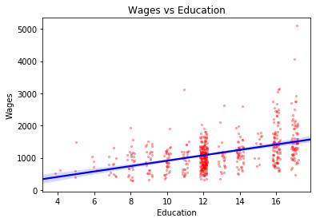

```python
# use line_kws= {'color':'blue'} to change color of the line
# scatter_kws={'color':'red', 's':5} to change color and size of dots

sns.regplot(x="education", y="wage", data=PSID1982,line_kws= {'color':'blue'},marker='o',
           scatter_kws={'color':'red', 's':5, 'alpha':0.3}, x_jitter = 0.2).set(title= 'Wages vs Education',
                                                  xlabel="Education", ylabel = "Wages");
```

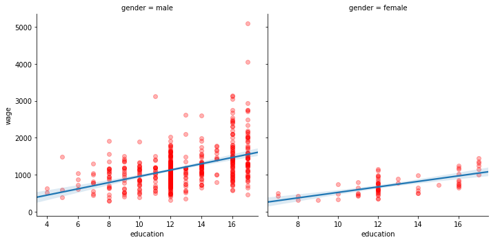

```python
sns.lmplot(x="education", y="wage", col="gender", scatter_kws={'color':'red','alpha':0.3},
            sharex=False,  data=PSID1982).add_legend();
```

# Simple regression analysis

Now let's use the data to estimate the following equation $$ wage = \beta_0 + \beta_1*education + u $$

Estimate this equation using the step by step method learned last class, the method that minimizes SSR and the variance covarance method. (3 ways first)

### Equation system results: step-by-step

```python
y = PSID1982["wage"]
x = PSID1982["education"]

# ingredients to the OLS formulas:
sumxy = np.sum( (x-np.mean(x)) * (y-np.mean(y)) )
sumx2 =  np.sum ((x-np.mean(x)) **2)
sumy2 =  np.sum ((y-np.mean(y)) **2)
x_bar = np.mean(x)
y_bar = np.mean(y)


# manual calculation of OLS coefficients:
b1 = sumxy/sumx2
b0 = y_bar - b1 * x_bar

print(f'b1: {b1}\n')
print(f'b0: {b0}\n')
```

```
b1: 83.88785655141531

b0: 70.4674157605591
```

### Function minimization results

```python
#Create initial values for the Beta parameters
b = np.array([0.5,0.5])

#create a column of constants
k= np.ones(len(x))

# Create function for Sum of square residuals (SSR)
def sse(b,y,x,k):
    return np.sum((y-b[0]*k-b[1]*x)**2)

#Use minimize from scipy.optimize to find the parameters beta that minimize the SSR
resa = minimize(fun=sse,
                args= (y, x, k),
                x0 =b)

# print results
print(resa['x'])
```

```
[70.46925847 83.88772698]
```

### Covariance , variance method

Using the `np.cov(x,y)` and `np.var(x)` functions in Python calculate the $\hat\beta_0, \hat\beta_1$ based on the equation below. $$\hat\beta_1=\frac{Cov(x,y)}{Var(x)}$$ $$\hat\beta_0 = \bar{y} - \hat\beta_1 \bar{x}$$

```python
# ingredients to the OLS formulas:
cov_xy = np.cov(x,y)[1,0]  # access 2. row and 1. column of covariance matrix
var_x = np.var(x,ddof=1)
x_bar = np.mean(x)
y_bar = np.mean(y)

# manual calculation of OLS coefficients:
b1 = cov_xy / var_x
b0 = y_bar - b1 * x_bar
print(f'b1: {b1}\n')
print(f'b0: {b0}\n')
```

```
b1: 83.8878565514152

b0: 70.4674157605607
```

### `ols()` command

Finally use the `ols()` command to estimate save your estimation in an object called reg and show the summary of your model. $$ log(wage) = \beta_0 + \beta_1*education + u $$ What can you say about this new results why is it better to use $log(wages)$? What is your interpretation of the coeficients and the $R^2$?

-- The new results have smaller coefficients for x and intercepts.

-- Using the natural logarithm of y can transform unit change to percent change of wages for every one-unit change of education. Thus, logarithmic transformation is a convenient means of transforming a highly skewed variable into a more normalized dataset.

-- The coefficient of intercept denotes the value of log(wage) when the education takes the value 0 (which is not really meaningful because no one would have absolutely no education), while the coefficient of x represents the slope of the regression line: it means that for every one-unit change in education, the wage will increase by 7.17% . The R-squared is the proportion of the variance in the dependent variable that the independent variables explain, which in this case means that 20.8% of the variance in y (log(wage)) could be explained by x (education).

```python
# estimate log-level model:
data = {"x": x, "np.log(y)": np.log(y)}

# Put all vectors into a data frame to work with it later
# and becasue you need that format for the graphs
datas = pd.DataFrame(data)
reg = smf.ols(formula = 'np.log(y) ~ x', data = datas)
results = reg.fit()

# print results using summary:
print(f'results.summary(): \n{results.summary()}\n')
```

```
results.summary():
                            OLS Regression Results
==============================================================================
Dep. Variable:              np.log(y)   R-squared:                       0.208
Model:                            OLS   Adj. R-squared:                  0.207
Method:                 Least Squares   F-statistic:                     156.2
Date:                Wed, 24 Feb 2021   Prob (F-statistic):           5.64e-32
Time:                        11:00:29   Log-Likelihood:                -283.58
No. Observations:                 595   AIC:                             571.2
Df Residuals:                     593   BIC:                             579.9
Df Model:                           1
Covariance Type:            nonrobust
==============================================================================
                 coef    std err          t      P>|t|      [0.025      0.975]
------------------------------------------------------------------------------
Intercept      6.0292      0.075     79.899      0.000       5.881       6.177
x              0.0717      0.006     12.497      0.000       0.060       0.083
==============================================================================
Omnibus:                        2.787   Durbin-Watson:                   1.839
Prob(Omnibus):                  0.248   Jarque-Bera (JB):                2.604
Skew:                          -0.153   Prob(JB):                        0.272
Kurtosis:                       3.105   Cond. No.                         62.3
==============================================================================

Warnings:
[1] Standard Errors assume that the covariance matrix of the errors is correctly specified.
```

**Packages used in this document** `wooldridge` `matplot.lib` `pandas` `numpy` `seaborn`

ECON320 Python Programming Laboratory

Professor *Paloma Lopez de mesa Moyano*

*paloma.moyano@emory.edu*

Department of Economics

Emory University

```python
 !jupyter nbconvert --to html  "Assignment 1 Sam Hu.ipynb"
```

```
[NbConvertApp] Converting notebook Assignment 1 Sam Hu.ipynb to html
[NbConvertApp] Writing 374665 bytes to Assignment 1 Sam Hu.html
```